# Practical Machine Learning Wk 4 Proj

SNG JUN QIANG

9 March 2019

### 1. Background

Devices such as Jawbone Up, Nike FuelBand, and Fitbit is collecting large amount of data about personal activity relatively inexpensively. These devices are part of the quantified self movement – a group of enthusiasts who take measurements about themselves regularly to improve their health, to find patterns in their behavior, or because they are tech geeks. One thing that people regularly do is quantify how much of a particular activity they do, but they rarely quantify how well they do it.

### 2. Objective

Using data from accelerometers on the belt, forearm, arm, and dumbell of 6 participants to predict the manner in which they did the exercise. They were asked to perform barbell lifts correctly and incorrectly in 5 different ways. More information is available from the website here: http://web.archive.org/web/20161224072740/http:/groupware.les.inf.puc-rio.br/har (see the section on the Weight Lifting Exercise Dataset).

### 3. Data Source

The training data for this project are available here: https://d396qusza40orc.cloudfront.net/predmachlearn/pml-training.csv

The test data are available here: https://d396qusza40orc.cloudfront.net/predmachlearn/pml-testing.csv

Citation: http://web.archive.org/web/20161224072740/http:/groupware.les.inf.puc-rio.br/har.

### 4. LIbraries

```r
library(RColorBrewer)
library(caret)
```

```r
library(rpart)
library(rpart.plot)
library(randomForest)
```

### 5. Loading Data

Loading driectly from web and downloaded as data frame.

```r
TrainURL <- "http://d396qusza40orc.cloudfront.net/predmachlearn/pml-training.csv"
TestURL  <- "http://d396qusza40orc.cloudfront.net/predmachlearn/pml-testing.csv"
Train <- read.csv(url(TrainURL))
Test <- read.csv(url(TestURL))
```

### 6. Data Exploration and Processing

```r
dim(Train)
```

```
## [1] 19622   160
```

```r
dim(Test)
```

```
## [1]  20 160
```

```r
sum(is.na(Train))
```

```
## [1] 1287472
```

```r
sum(is.na(Test))
```

```
## [1] 2000
```

```r
table(Train$classe)
```

```
##
##    A    B    C    D    E
## 5580 3797 3422 3216 3607
```

```r
str(Train$classe)
```

```
##  Factor w/ 5 levels "A","B","C","D",..: 1 1 1 1 1 1 1 1 1 1 ...
```

```r
sum(is.na(Train$classe))
```

```
## [1] 0
```

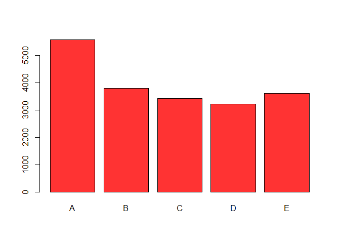

```r
plot(Train$classe, col="#FF3333")
```

Removing unecessary columns for both Train and Test. Replacing blank cell with NA. Converting all predictors to numeric.

```r
Sub_Train <- Train[,-c(1:7)]
Sub_Train[Sub_Train == ""] <- NA
Sub_Train[, 1:152] <- sapply(Sub_Train[, 1:152], as.numeric)
Sub_Train[is.na(Sub_Train)] <- 0
sum(is.na(Sub_Train))
```

```
## [1] 0
```

```r
Sub_Test <- Test[,-c(1:7)]
Sub_Test[Sub_Test == ""] <- NA
Sub_Test[, 1:152] <- sapply(Sub_Test[, 1:152], as.numeric)
Sub_Test[is.na(Sub_Test)] <- 0
sum(is.na(Sub_Test))
```

```
## [1] 0
```

### 7. Cross Validation Set

```r
set.seed(123)
Index <- createDataPartition(Sub_Train$classe, p=0.75)[[1]]
Index_Sub_Train <- Sub_Train[Index,]
Index_Sub_Train_CROSSV <- Sub_Train[-Index,]
dim(Index_Sub_Train)
```

```
## [1] 14718   153
```

```r
dim(Index_Sub_Train_CROSSV)
```

```
## [1] 4904  153
```

### 8. Decision Tree Model

```r
DT <- train(classe ~ ., data = Index_Sub_Train, method="rpart")
DT_predict <- predict(DT, Index_Sub_Train_CROSSV)
confusionMatrix(DT_predict, Index_Sub_Train_CROSSV$classe)
```

```
## Confusion Matrix and Statistics
##
##           Reference
## Prediction    A    B    C    D    E
##          A 1262  378  418  356  144
##          B   20  312   26  141  101
##          C  107  259  411  307  248
##          D    0    0    0    0    0
##          E    6    0    0    0  408
##
## Overall Statistics
##
##                Accuracy : 0.488
##                  95% CI : (0.4739, 0.5021)
##     No Information Rate : 0.2845
##     P-Value [Acc > NIR] : < 2.2e-16
##
##                   Kappa : 0.3307
##  Mcnemar's Test P-Value : NA
##
## Statistics by Class:
##
##                      Class: A Class: B Class: C Class: D Class: E
## Sensitivity            0.9047  0.32877  0.48070   0.0000  0.45283
## Specificity            0.6307  0.92718  0.77254   1.0000  0.99850
## Pos Pred Value         0.4934  0.52000  0.30856      NaN  0.98551
## Neg Pred Value         0.9433  0.85200  0.87570   0.8361  0.89020
## Prevalence             0.2845  0.19352  0.17435   0.1639  0.18373
## Detection Rate         0.2573  0.06362  0.08381   0.0000  0.08320
## Detection Prevalence   0.5216  0.12235  0.27162   0.0000  0.08442
## Balanced Accuracy      0.7677  0.62797  0.62662   0.5000  0.72567
```

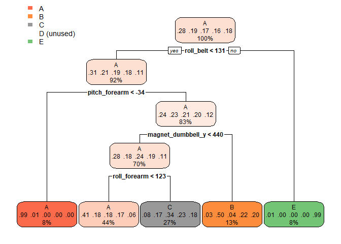

```r
rpart.plot(DT$finalModel, roundint=FALSE)
```

### 9. Random Forest Model

```r
RF <- train(classe ~ ., data = Index_Sub_Train, method = "rf", ntree = 100)
RF_predict <- predict(RF, Index_Sub_Train_CROSSV)
confusionMatrix(RF_predict, Index_Sub_Train_CROSSV$classe)
```

```
## Confusion Matrix and Statistics
##
##           Reference
## Prediction    A    B    C    D    E
##          A 1394    5    0    0    0
##          B    1  943    4    0    0
##          C    0    1  848    7    0
##          D    0    0    3  796    2
##          E    0    0    0    1  899
##
## Overall Statistics
##
##                Accuracy : 0.9951
##                  95% CI : (0.9927, 0.9969)
##     No Information Rate : 0.2845
##     P-Value [Acc > NIR] : < 2.2e-16
##
##                   Kappa : 0.9938
##  Mcnemar's Test P-Value : NA
##
## Statistics by Class:
##
##                      Class: A Class: B Class: C Class: D Class: E
## Sensitivity            0.9993   0.9937   0.9918   0.9900   0.9978
## Specificity            0.9986   0.9987   0.9980   0.9988   0.9998
## Pos Pred Value         0.9964   0.9947   0.9907   0.9938   0.9989
## Neg Pred Value         0.9997   0.9985   0.9983   0.9981   0.9995
## Prevalence             0.2845   0.1935   0.1743   0.1639   0.1837
## Detection Rate         0.2843   0.1923   0.1729   0.1623   0.1833
## Detection Prevalence   0.2853   0.1933   0.1746   0.1633   0.1835
## Balanced Accuracy      0.9989   0.9962   0.9949   0.9944   0.9988
```

### 11. Applying Random Forest Model to Final Prediction

```r
Final_Predict <- predict(RF,Sub_Test)
Final_Predict
```

```
##  [1] B A B A A E D B A A B C B A E E A B B B
## Levels: A B C D E
```